# Week 2 Quiz

## Q2

A collaborator sends you a file containing data for three years of average race finish times.

```
age_group,2015,2016,2017
20,3:46,3:22,3:50
30,3:50,3:43,4:43
40,4:39,3:49,4:51
50,4:48,4:59,5:01
```

Reading the above data and converting it to tidy.

We have saved this data to `race_finish.csv`. Reading the CSV file.

```r
wide_dat <- read_csv("race_finish.csv")
head(wide_dat)
```

| age_group | 2015 | 2016 | 2017 |
| --- | --- | --- | --- |
| 20 | 03:46:00 | 03:22:00 | 03:50:00 |
| 30 | 03:50:00 | 03:43:00 | 04:43:00 |
| 40 | 04:39:00 | 03:49:00 | 04:51:00 |
| 50 | 04:48:00 | 04:59:00 | 05:01:00 |

Converting the wide data table to tidy

```r
races_dat <- wide_dat %>%
    pivot_longer(-age_group, names_to = "year", values_to = "Time")
races_dat$year <- as.integer(races_dat$year)
races_dat$age_group <- as.integer(races_dat$age_group)
races_dat
```

| age_group | year | Time |
| --- | --- | --- |
| 20 | 2015 | 03:46:00 |
| 20 | 2016 | 03:22:00 |
| 20 | 2017 | 03:50:00 |
| 30 | 2015 | 03:50:00 |
| 30 | 2016 | 03:43:00 |
| 30 | 2017 | 04:43:00 |
| 40 | 2015 | 04:39:00 |
| 40 | 2016 | 03:49:00 |
| 40 | 2017 | 04:51:00 |
| 50 | 2015 | 04:48:00 |

[output cut: 2 more lines]

## Q6

You have a dataset on U.S. contagious diseases, but it is in the following wide format:

[output not shown]

Data saved in `us_disease.tsv`

```r
d <- read_csv("us_disease.tsv")
d
```

| state | year | population | HepatitisA | Mumps | Polio | Rubella |
| --- | --- | --- | --- | --- | --- | --- |
| Alabama | 1990 | 4040587 | 89 | 19 | 76 | 1 |
| Alabama | 1991 | 4066003 | 39 | 14 | 65 | 0 |
| Alabama | 1992 | 4097169 | 35 | 12 | 24 | 0 |
| Alabama | 1993 | 4133242 | 42 | 22 | 67 | 0 |
| Alabama | 1994 | 4173361 | 72 | 12 | 39 | 0 |
| Alabama | 1995 | 4216645 | 75 | 2 | 38 | 0 |

You want to transform this into a tidy dataset, with each row representing an observation of the incidence of each specific disease (as shown below):

[output not shown]

```r
d %>%
    pivot_longer(HepatitisA:Rubella, names_to = "disease", values_to = "count")
```

| state | year | population | disease | count |
| --- | --- | --- | --- | --- |
| Alabama | 1990 | 4040587 | HepatitisA | 89 |
| Alabama | 1990 | 4040587 | Mumps | 19 |
| Alabama | 1990 | 4040587 | Polio | 76 |
| Alabama | 1990 | 4040587 | Rubella | 1 |
| Alabama | 1991 | 4066003 | HepatitisA | 39 |
| Alabama | 1991 | 4066003 | Mumps | 14 |
| Alabama | 1991 | 4066003 | Polio | 65 |
| Alabama | 1991 | 4066003 | Rubella | 0 |
| Alabama | 1992 | 4097169 | HepatitisA | 35 |
| Alabama | 1992 | 4097169 | Mumps | 12 |

[output cut: 14 more lines]

## Q7

Reading races data and converting it to tidy.

```r
wide_dat <- read_csv("race_finish.csv")
head(wide_dat)
```

| age_group | 2015 | 2016 | 2017 |
| --- | --- | --- | --- |
| 20 | 03:46:00 | 03:22:00 | 03:50:00 |
| 30 | 03:50:00 | 03:43:00 | 04:43:00 |
| 40 | 04:39:00 | 03:49:00 | 04:51:00 |
| 50 | 04:48:00 | 04:59:00 | 05:01:00 |

```r
races_dat <- wide_dat %>%
    pivot_longer(-age_group, names_to = "year", values_to = "Time")
races_dat
```

| age_group | year | Time |
| --- | --- | --- |
| 20 | 2015 | 03:46:00 |
| 20 | 2016 | 03:22:00 |
| 20 | 2017 | 03:50:00 |
| 30 | 2015 | 03:50:00 |
| 30 | 2016 | 03:43:00 |
| 30 | 2017 | 04:43:00 |
| 40 | 2015 | 04:39:00 |
| 40 | 2016 | 03:49:00 |
| 40 | 2017 | 04:51:00 |
| 50 | 2015 | 04:48:00 |

[output cut: 2 more lines]

Converting races tidy table to wide table, where each year has a separate column.

```r
races_dat %>%
    pivot_wider(names_from = year, values_from = Time)
```

| age_group | 2015 | 2016 | 2017 |
| --- | --- | --- | --- |
| 20 | 03:46:00 | 03:22:00 | 03:50:00 |
| 30 | 03:50:00 | 03:43:00 | 04:43:00 |
| 40 | 04:39:00 | 03:49:00 | 04:51:00 |
| 50 | 04:48:00 | 04:59:00 | 05:01:00 |

## Q9

A collaborator sends you a file containing data for two years of average race finish times, “times.csv”:

```
age_group,2015_time,2015_participants,2016_time,2016_participants
20,3:46,54,3:22,62
30,3:50,60,3:43,58
40,4:39,29,3:49,33
50,4:48,10,4:59,14
```

```r
d <- read_csv("times.csv", col_types="dcccc")
d
```

| age_group | 2015_time | 2015_participants | 2016_time | 2016_participants |
| --- | --- | --- | --- | --- |
| 20 | 3:46 | 54 | 3:22 | 62 |
| 30 | 3:50 | 60 | 3:43 | 58 |
| 40 | 4:39 | 29 | 3:49 | 33 |
| 50 | 4:48 | 10 | 4:59 | 14 |

```r
d %>%
    pivot_longer(-age_group, names_to = 'key', values_to = 'value') %>%
    separate(col = key, into = c('year', 'variable_name')) %>%
    pivot_wider(names_from = variable_name, values_from = value)
```

| age_group | year | time | participants |
| --- | --- | --- | --- |
| 20 | 2015 | 3:46 | 54 |
| 20 | 2016 | 3:22 | 62 |
| 30 | 2015 | 3:50 | 60 |
| 30 | 2016 | 3:43 | 58 |
| 40 | 2015 | 4:39 | 29 |
| 40 | 2016 | 3:49 | 33 |
| 50 | 2015 | 4:48 | 10 |
| 50 | 2016 | 4:59 | 14 |

# Q11

Importing co2

```r
co2_wide <- co2
```

```r
co2_wide <- data.frame(matrix(co2, ncol = 12, byrow = TRUE)) %>%
    setNames(1:12) %>%
    mutate(year = as.character(1959:1997))

head(co2_wide)
```

|  | 1 | 2 | 3 | 4 | 5 | 6 | 7 | 8 | 9 | 10 | 11 | 12 | year |
| --- | --- | --- | --- | --- | --- | --- | --- | --- | --- | --- | --- | --- | --- |
| 1 | 315.42 | 316.31 | 316.50 | 317.56 | 318.13 | 318.00 | 316.39 | 314.65 | 313.68 | 313.18 | 314.66 | 315.43 | 1959 |
| 2 | 316.27 | 316.81 | 317.42 | 318.87 | 319.87 | 319.43 | 318.01 | 315.74 | 314.00 | 313.68 | 314.84 | 316.03 | 1960 |
| 3 | 316.73 | 317.54 | 318.38 | 319.31 | 320.42 | 319.61 | 318.42 | 316.63 | 314.83 | 315.16 | 315.94 | 316.85 | 1961 |
| 4 | 317.78 | 318.40 | 319.53 | 320.42 | 320.85 | 320.45 | 319.45 | 317.25 | 316.11 | 315.27 | 316.53 | 317.53 | 1962 |
| 5 | 318.58 | 318.92 | 319.70 | 321.22 | 322.08 | 321.31 | 319.58 | 317.61 | 316.05 | 315.83 | 316.91 | 318.20 | 1963 |
| 6 | 319.41 | 320.07 | 320.74 | 321.40 | 322.06 | 321.73 | 320.27 | 318.54 | 316.54 | 316.71 | 317.53 | 318.55 | 1964 |

Converting to tidy form

```r
co2_tidy <- pivot_longer(co2_wide, -year, names_to = "month", values_to = "co2")
head(co2_tidy)
```

| year | month | co2 |
| --- | --- | --- |
| 1959 | 1 | 315.42 |
| 1959 | 2 | 316.31 |
| 1959 | 3 | 316.50 |
| 1959 | 4 | 317.56 |
| 1959 | 5 | 318.13 |
| 1959 | 6 | 318.00 |

# Q 13

Use co2_tidy to plot CO2 versus month with a different curve for each year:

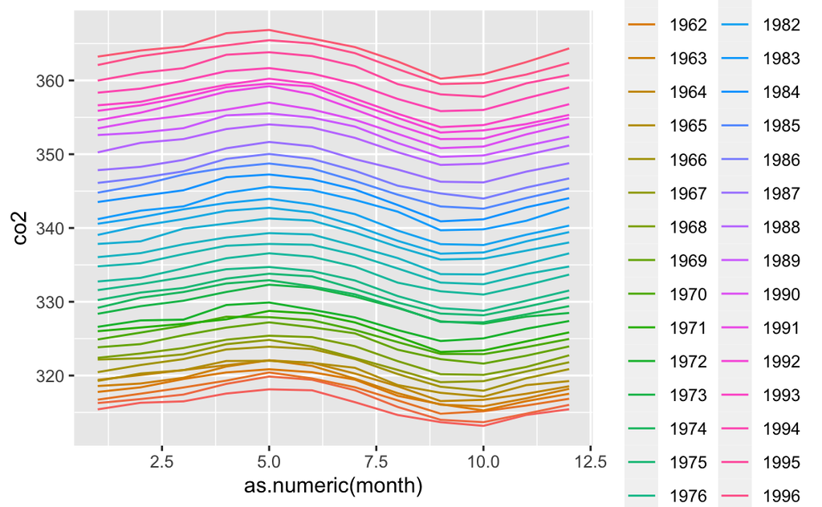

```r
co2_tidy %>% ggplot(aes(as.numeric(month), co2, color = year)) + geom_line()
```

# Q 14

Load the admissions dataset from dslabs, which contains college admission information for men and women across six majors, and remove the applicants percentage column:

```r
library(dslabs)
data(admissions)
dat <- admissions %>% select(-applicants)
```

Your goal is to get the data in the shape that has one row for each major, like this:

```
major  men   women
A      62    82
B      63    68
C      37    34
D      33    35
E      28    24
F       6     7
```

```r
head(dat)
```

|  | major | gender | admitted |
| --- | --- | --- | --- |
| 1 | A | men | 62 |
| 2 | B | men | 63 |
| 3 | C | men | 37 |
| 4 | D | men | 33 |
| 5 | E | men | 28 |
| 6 | F | men | 6 |

Using `pivot_wider`

```r
dat_tidy <- pivot_wider(dat, names_from = gender, values_from = admitted)
dat_tidy
```

| major | men | women |
| --- | --- | --- |
| A | 62 | 82 |
| B | 63 | 68 |
| C | 37 | 34 |
| D | 33 | 35 |
| E | 28 | 24 |
| F | 6 | 7 |

# Q 15

Now use the admissions dataset to create the object tmp, which has columns major, gender, key and value:

```r
tmp <- admissions %>%
  pivot_longer(cols = c(admitted, applicants), names_to = "key", values_to = "value")
tmp
```

| major | gender | key | value |
| --- | --- | --- | --- |
| A | men | admitted | 62 |
| A | men | applicants | 825 |
| B | men | admitted | 63 |
| B | men | applicants | 560 |
| C | men | admitted | 37 |
| C | men | applicants | 325 |
| D | men | admitted | 33 |
| D | men | applicants | 417 |
| E | men | admitted | 28 |
| E | men | applicants | 191 |

[output cut: 14 more lines]

Combine the key and gender and create a new column called `column_name` to get a variable with the following values: `admitted_men`, `admitted_women`, `applicants_men`, and `applicants_women`. Save the new data as `tmp2`.

```r
tmp2 <- unite(tmp, 'column_name', c(key, gender))
tmp2
```

| major | column_name | value |
| --- | --- | --- |
| A | admitted_men | 62 |
| A | applicants_men | 825 |
| B | admitted_men | 63 |
| B | applicants_men | 560 |
| C | admitted_men | 37 |
| C | applicants_men | 325 |
| D | admitted_men | 33 |
| D | applicants_men | 417 |
| E | admitted_men | 28 |
| E | applicants_men | 191 |

[output cut: 14 more lines]

## Q 16

Which function can reshape `tmp2` to a table with six rows and five columns named `major`, `admitted_men`, `admitted_women`, `applicants_men`, and `applicants_women`?

Converting tidy to wide tade

```r
tmp3 <- pivot_wider(tmp2, names_from = column_name, values_from = value)
tmp3
```

| major | admitted_men | applicants_men | admitted_women | applicants_women |
| --- | --- | --- | --- | --- |
| A | 62 | 825 | 82 | 108 |
| B | 63 | 560 | 68 | 25 |
| C | 37 | 325 | 34 | 593 |
| D | 33 | 417 | 35 | 375 |
| E | 28 | 191 | 24 | 393 |
| F | 6 | 373 | 7 | 341 |